# The Human Smokestack

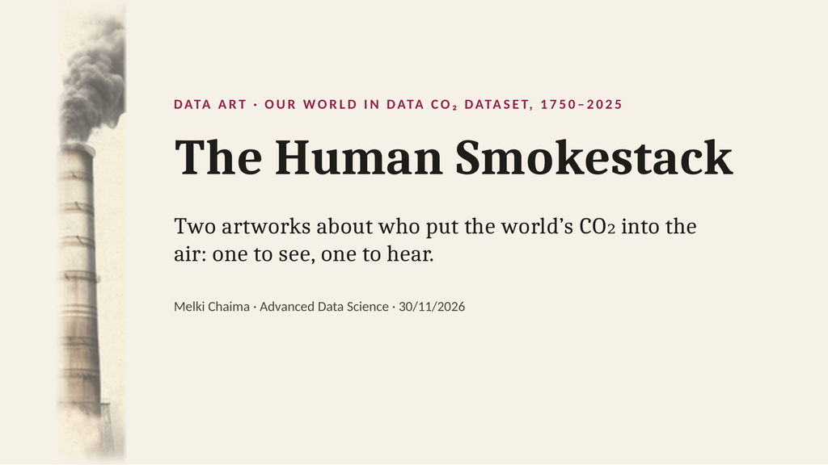

[Image: A factory chimney with dark smoke rising from it]

DATA ART · OUR WORLD IN DATA CO₂ DATASET, 1750–2025

The Human Smokestack

Two artworks about who put the world’s CO₂ into the air: one to see, one to hear.

Melki Chaima · Advanced Data Science · 30/11/2026

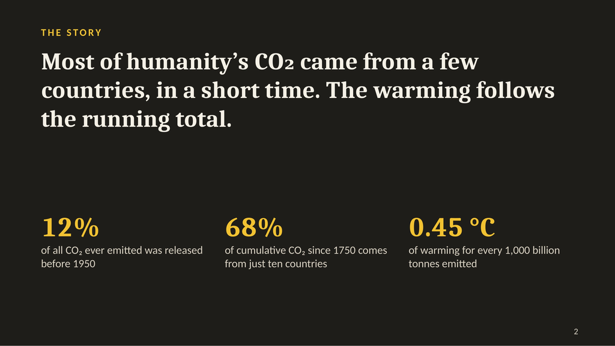

THE STORY

Most of humanity’s CO₂ came from a few countries, in a short time. The warming follows the running total.

12%

of all CO₂ ever emitted was released before 1950

68%

of cumulative CO₂ since 1750 comes from just ten countries

0.45 °C

of warming for every 1,000 billion tonnes emitted

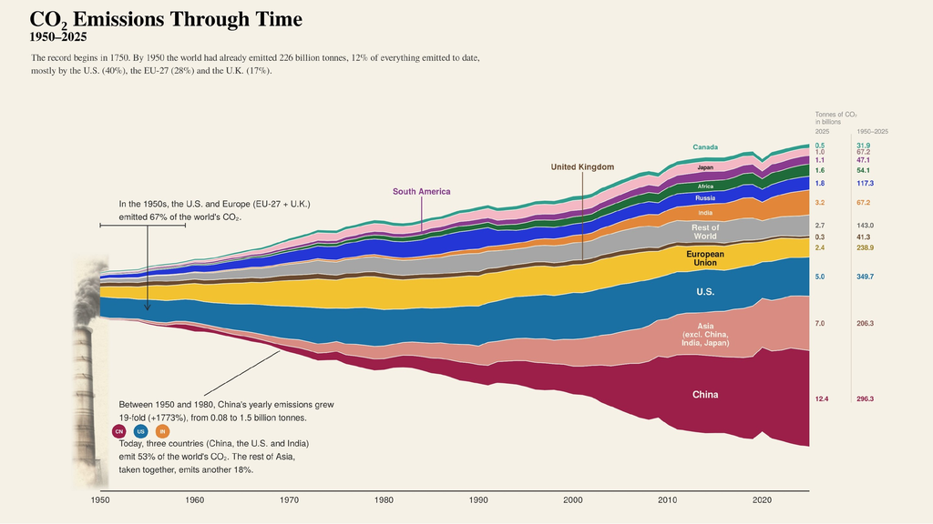

[Image: The artwork: a streamgraph of CO₂ emissions by region from 1950 to 2025 pouring out of a factory chimney, each band labelled and ending in its 2025 and cumulative totals]

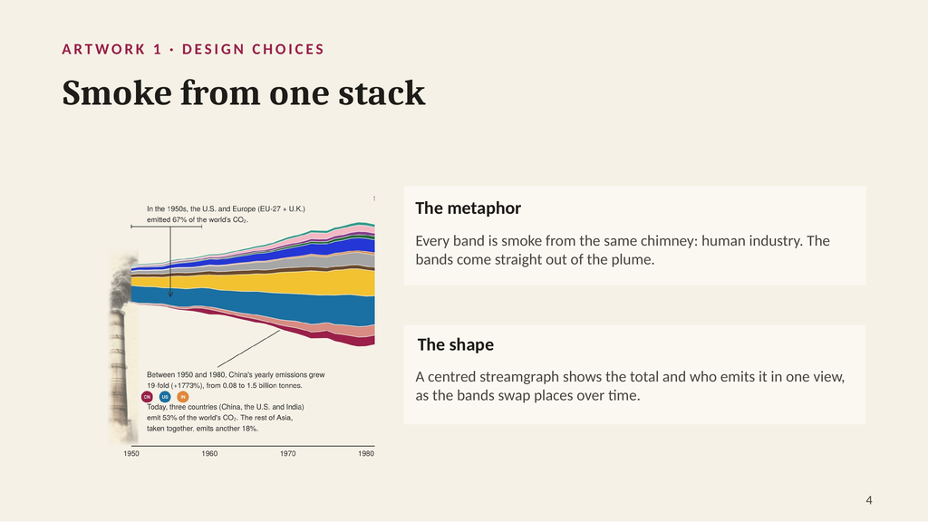

ARTWORK 1 · DESIGN CHOICES

Smoke from one stack

[Image: Detail of the artwork: the chimney’s smoke runs into the start of the stream, with call-outs about the 1950s and about China written in the cream space]

The metaphor

Every band is smoke from the same chimney: human industry. The bands come straight out of the plume.

The shape

A centred streamgraph shows the total and who emits it in one view, as the bands swap places over time.

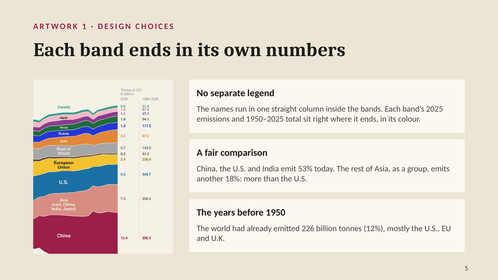

ARTWORK 1 · DESIGN CHOICES

Each band ends in its own numbers

[Image: Detail of the artwork’s right edge: region names in a column inside the bands, and beside each band its 2025 emissions and 1950–2025 total in the band’s colour]

No separate legend

The names run in one straight column inside the bands. Each band’s 2025 emissions and 1950–2025 total sit right where it ends, in its colour.

A fair comparison

China, the U.S. and India emit 53% today. The rest of Asia, as a group, emits another 18%: more than the U.S.

The years before 1950

The world had already emitted 226 billion tonnes (12%), mostly the U.S., EU and U.K.

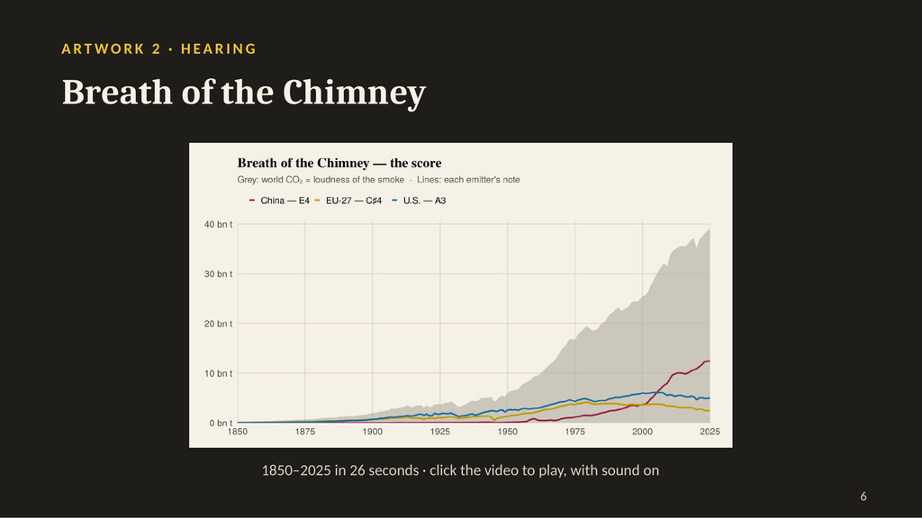

[video not shown]

ARTWORK 2 · HEARING

Breath of the Chimney

1850–2025 in 26 seconds · click the video to play, with sound on

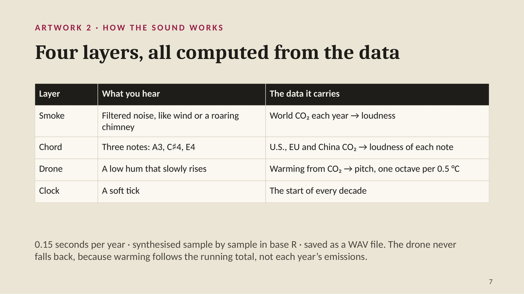

ARTWORK 2 · HOW THE SOUND WORKS

Four layers, all computed from the data

Layer | What you hear | The data it carries

Smoke | Filtered noise, like wind or a roaring chimney | World CO₂ each year → loudness

Chord | Three notes: A3, C♯4, E4 | U.S., EU and China CO₂ → loudness of each note

Drone | A low hum that slowly rises | Warming from CO₂ → pitch, one octave per 0.5 °C

Clock | A soft tick | The start of every decade

0.15 seconds per year · synthesised sample by sample in base R · saved as a WAV file. The drone never falls back, because warming follows the running total, not each year’s emissions.

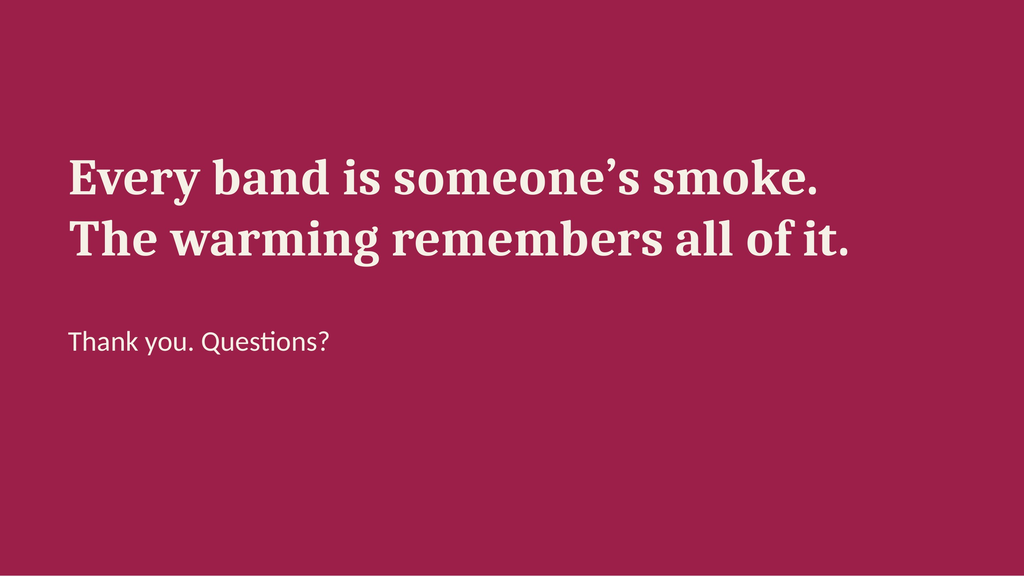

Every band is someone’s smoke. The warming remembers all of it.

Thank you. Questions?